# SR_02_RLTD_ORG_ADDR_ZIP

Related organization zip · Identifier report

## Overview

**Description**

Address Foreign - Postal code

**Table**

`SR-P02-T01-ID-RLTD-TAX-EXEMPED-ORGS` (many)

**Location code**

`SCHED-R-PART-02-COL-A`

**Family**

`SCHED-R-PART-02-COL-A` · siblings: SR_02_RLTD_ORG_ADDR_CITY, SR_02_RLTD_ORG_ADDR_CNTR, SR_02_RLTD_ORG_ADDR_L1, SR_02_RLTD_ORG_ADDR_L2, SR_02_RLTD_ORG_ADDR_STATE, SR_02_RLTD_ORG_EIN

**Data type**

text (xsd: TextType, ZIPCodeType)

**Scope**

PC

**Status**

unreviewed

6

xpaths mapped (6 observed)

840,378

filings with a value

2009–2024

tax years observed

3

open flags (1 errors)

## Flags

| Severity | Flag | Xpath | Detail |
| --- | --- | --- | --- |
| ⚠ error | `COLLISION` | IRS990ScheduleR/IdRelatedTaxExemptOrgGrp/ForeignAddress/ForeignPostalCd | 4626 filings contain 2+ of its xpaths; most common set: /Return/ReturnData/IRS990ScheduleR/IdRelatedTaxExemptOrgGrp/ForeignAddress/ForeignPostalCd ; /Return/ReturnData/IRS990ScheduleR/IdRelatedTaxExem… |
| ⓘ info | `MANY_NOT_REPEATING` | IRS990ScheduleR/IdRelatedTaxExemptOrgGrp/USAddress/ZIPCd | many-to-one table, but 52% of values sit in no repeating element |
| ⓘ info | `MANY_NOT_REPEATING` | IRS990ScheduleR/IdRelatedTaxExemptOrgGrp/USAddress/ZIPCode | many-to-one table, but 50% of values sit in no repeating element |

## Xpaths

All mapped xpaths (under /Return/ReturnData or /Return/ReturnHeader), oldest first. Charts label each series by its xpath.

| Xpath | Form | Chart label | First year | Last year | Versions | Filings | Repeats in |
| --- | --- | --- | --- | --- | --- | --- | --- |
| IRS990ScheduleR/Form990ScheduleRPartII/AddressUS/ZIPCode | Sched R | same | 2009 | 2012 | 18 | 132,312 | 51.3% |
| IRS990ScheduleR/Form990ScheduleRPartII/AddressForeign/PostalCode | Sched R | …cheduleR/Form990ScheduleRPartII/AddressForeign/PostalCode | 2009 | 2012 | 14 | 973 | 29.1% |
| IRS990ScheduleR/IdRelatedTaxExemptOrgGrp/USAddress/ZIPCode | Sched R | same | 2013 | 2013 | 3 | 47,596 | 49.2% |
| IRS990ScheduleR/IdRelatedTaxExemptOrgGrp/ForeignAddress/PostalCode | Sched R | …eduleR/IdRelatedTaxExemptOrgGrp/ForeignAddress/PostalCode | 2013 | 2013 | 3 | 399 | 26.6% |
| IRS990ScheduleR/IdRelatedTaxExemptOrgGrp/USAddress/ZIPCd | Sched R | same | 2014 | 2024 | 34 | 651,290 | 47.9% |
| IRS990ScheduleR/IdRelatedTaxExemptOrgGrp/ForeignAddress/ForeignPostalCd | Sched R | …R/IdRelatedTaxExemptOrgGrp/ForeignAddress/ForeignPostalCd | 2014 | 2024 | 33 | 7,808 | 29.1% |

## Coverage

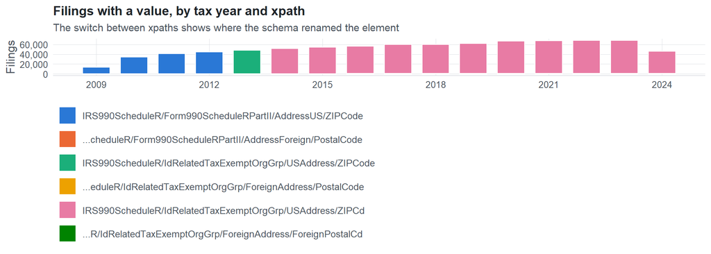

**Table view**

Table view: filings by tax year and series

| Tax year | IRS990ScheduleR/Form990ScheduleRPartII/AddressUS/ZIPCode | …cheduleR/Form990ScheduleRPartII/AddressForeign/PostalCode | IRS990ScheduleR/IdRelatedTaxExemptOrgGrp/USAddress/ZIPCode | …eduleR/IdRelatedTaxExemptOrgGrp/ForeignAddress/PostalCode | IRS990ScheduleR/IdRelatedTaxExemptOrgGrp/USAddress/ZIPCd | …R/IdRelatedTaxExemptOrgGrp/ForeignAddress/ForeignPostalCd |
| --- | --- | --- | --- | --- | --- | --- |
| 2009 | 13,294 | 102 | 0 | 0 | 0 | 0 |
| 2010 | 33,609 | 224 | 0 | 0 | 0 | 0 |
| 2011 | 40,919 | 309 | 0 | 0 | 0 | 0 |
| 2012 | 44,490 | 338 | 0 | 0 | 0 | 0 |
| 2013 | 0 | 0 | 47,596 | 399 | 0 | 0 |
| 2014 | 0 | 0 | 0 | 0 | 51,116 | 459 |
| 2015 | 0 | 0 | 0 | 0 | 53,523 | 531 |
| 2016 | 0 | 0 | 0 | 0 | 55,448 | 585 |
| 2017 | 0 | 0 | 0 | 0 | 58,874 | 654 |
| 2018 | 0 | 0 | 0 | 0 | 59,172 | 708 |
| 2019 | 0 | 0 | 0 | 0 | 60,848 | 757 |
| 2020 | 0 | 0 | 0 | 0 | 65,651 | 850 |
| 2021 | 0 | 0 | 0 | 0 | 66,652 | 873 |
| 2022 | 0 | 0 | 0 | 0 | 67,472 | 896 |
| 2023 | 0 | 0 | 0 | 0 | 67,375 | 911 |
| 2024 | 0 | 0 | 0 | 0 | 45,159 | 584 |

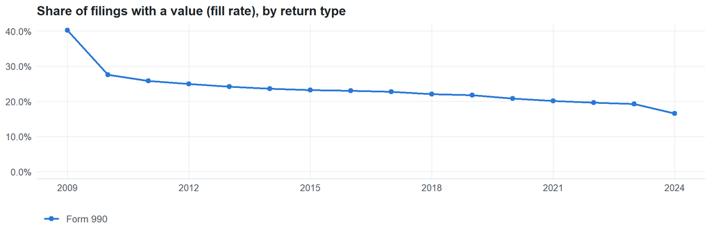

**Table view**

Table view: fill rate

| Tax year | Return type | Filings | All filings | Fill rate |
| --- | --- | --- | --- | --- |
| 2009 | Form 990 | 13,396 | 33,311 | 40.21% |
| 2010 | Form 990 | 33,833 | 123,025 | 27.50% |
| 2011 | Form 990 | 41,228 | 159,504 | 25.85% |
| 2012 | Form 990 | 44,828 | 179,688 | 24.95% |
| 2013 | Form 990 | 47,995 | 198,855 | 24.14% |
| 2014 | Form 990 | 51,575 | 218,619 | 23.59% |
| 2015 | Form 990 | 54,054 | 233,519 | 23.15% |
| 2016 | Form 990 | 56,033 | 243,903 | 22.97% |
| 2017 | Form 990 | 59,528 | 261,612 | 22.75% |
| 2018 | Form 990 | 59,880 | 271,442 | 22.06% |
| 2019 | Form 990 | 61,605 | 283,694 | 21.72% |
| 2020 | Form 990 | 66,501 | 320,342 | 20.76% |
| 2021 | Form 990 | 67,525 | 336,480 | 20.07% |
| 2022 | Form 990 | 68,368 | 349,055 | 19.59% |
| 2023 | Form 990 | 68,286 | 354,768 | 19.25% |
| 2024 | Form 990 | 45,743 | 277,298 | 16.50% |

## Repeating groups

Table cardinality in the concordance: **many**. 6 of 6 observed xpaths repeat within a filing.

Repeating element each xpath was observed in (from the raw indexed xpath)

| Xpath | Repeating element | Filings (summed over years) |
| --- | --- | --- |
| IRS990ScheduleR/Form990ScheduleRPartII/AddressForeign/PostalCode | (none) | 359 |
| IRS990ScheduleR/Form990ScheduleRPartII/AddressForeign/PostalCode | IRS990ScheduleR/Form990ScheduleRPartII | 614 |
| IRS990ScheduleR/Form990ScheduleRPartII/AddressUS/ZIPCode | (none) | 64031 |
| IRS990ScheduleR/Form990ScheduleRPartII/AddressUS/ZIPCode | IRS990ScheduleR/Form990ScheduleRPartII | 68281 |
| IRS990ScheduleR/IdRelatedTaxExemptOrgGrp/ForeignAddress/PostalCode | (none) | 142 |
| IRS990ScheduleR/IdRelatedTaxExemptOrgGrp/ForeignAddress/PostalCode | IRS990ScheduleR/IdRelatedTaxExemptOrgGrp | 257 |
| IRS990ScheduleR/IdRelatedTaxExemptOrgGrp/USAddress/ZIPCode | (none) | 23966 |
| IRS990ScheduleR/IdRelatedTaxExemptOrgGrp/USAddress/ZIPCode | IRS990ScheduleR/IdRelatedTaxExemptOrgGrp | 23630 |
| IRS990ScheduleR/IdRelatedTaxExemptOrgGrp/ForeignAddress/ForeignPostalCd | (none) | 2816 |
| IRS990ScheduleR/IdRelatedTaxExemptOrgGrp/ForeignAddress/ForeignPostalCd | IRS990ScheduleR/IdRelatedTaxExemptOrgGrp | 4992 |
| IRS990ScheduleR/IdRelatedTaxExemptOrgGrp/USAddress/ZIPCd | (none) | 336644 |
| IRS990ScheduleR/IdRelatedTaxExemptOrgGrp/USAddress/ZIPCd | IRS990ScheduleR/IdRelatedTaxExemptOrgGrp | 314646 |

## Values

| Result | Check | Detail |
| --- | --- | --- |
| ✓ pass | Values have the ZIP format | 99.4% of values match ^(99999\|999999999\|99999-9999)$ |
| ✓ pass | Stored as text | data type is text |
| ▲ warn | No placeholder values | 5 filings use a placeholder such as 000000000 |
| ⓘ info | Leading zeros present | at least 1% of values start with 0 in some year, so numeric storage would change them |

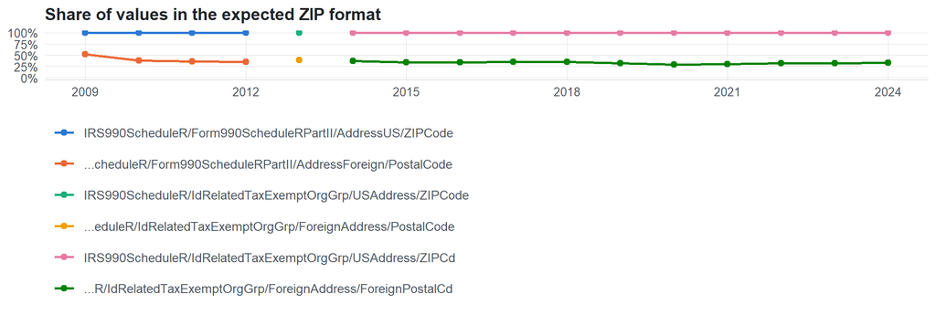

Value shapes (9 = digit, A = letter)

| Series | Shape | Expected | Filings |
| --- | --- | --- | --- |
| IRS990ScheduleR/Form990ScheduleRPartII/AddressUS/ZIPCode | 99999 | yes | 124,441 |
| IRS990ScheduleR/Form990ScheduleRPartII/AddressUS/ZIPCode | 999999999 | yes | 11,466 |
| …cheduleR/Form990ScheduleRPartII/AddressForeign/PostalCode | 99999 | yes | 309 |
| …cheduleR/Form990ScheduleRPartII/AddressForeign/PostalCode | A9A 9A9 | no | 188 |
| …cheduleR/Form990ScheduleRPartII/AddressForeign/PostalCode | 999999 | no | 122 |
| …cheduleR/Form990ScheduleRPartII/AddressForeign/PostalCode | 9999 | no | 103 |
| …cheduleR/Form990ScheduleRPartII/AddressForeign/PostalCode | AA9A 9AA | no | 91 |
| IRS990ScheduleR/IdRelatedTaxExemptOrgGrp/USAddress/ZIPCode | 99999 | yes | 44,941 |
| IRS990ScheduleR/IdRelatedTaxExemptOrgGrp/USAddress/ZIPCode | 999999999 | yes | 3,861 |
| …eduleR/IdRelatedTaxExemptOrgGrp/ForeignAddress/PostalCode | 99999 | yes | 124 |
| …eduleR/IdRelatedTaxExemptOrgGrp/ForeignAddress/PostalCode | A9A 9A9 | no | 70 |
| …eduleR/IdRelatedTaxExemptOrgGrp/ForeignAddress/PostalCode | 999999 | no | 52 |
| …eduleR/IdRelatedTaxExemptOrgGrp/ForeignAddress/PostalCode | 9999 | no | 39 |
| …eduleR/IdRelatedTaxExemptOrgGrp/ForeignAddress/PostalCode | AA9A 9AA | no | 32 |
| IRS990ScheduleR/IdRelatedTaxExemptOrgGrp/USAddress/ZIPCd | 99999 | yes | 620,523 |
| IRS990ScheduleR/IdRelatedTaxExemptOrgGrp/USAddress/ZIPCd | 999999999 | yes | 46,930 |
| …R/IdRelatedTaxExemptOrgGrp/ForeignAddress/ForeignPostalCd | 99999 | yes | 2,133 |
| …R/IdRelatedTaxExemptOrgGrp/ForeignAddress/ForeignPostalCd | A9A 9A9 | no | 1,413 |
| …R/IdRelatedTaxExemptOrgGrp/ForeignAddress/ForeignPostalCd | 999999 | no | 1,112 |
| …R/IdRelatedTaxExemptOrgGrp/ForeignAddress/ForeignPostalCd | 9999 | no | 1,110 |
| …R/IdRelatedTaxExemptOrgGrp/ForeignAddress/ForeignPostalCd | AA9A 9AA | no | 659 |
| …R/IdRelatedTaxExemptOrgGrp/ForeignAddress/ForeignPostalCd | A9A9A9 | no | 40 |

## Examples

| Tax year | Return | Xpath | Organization | Value | Source |
| --- | --- | --- | --- | --- | --- |
| 2024 | 990 | IRS990ScheduleR/IdRelatedTaxExemptOrgGrp/ForeignAddress/ForeignPostalCd | ACCION INTERNATIONAL | 560025 | [XML](https://gt990datalake-rawdata.s3.amazonaws.com/EfileData/XmlFiles/202503189349301700_public.xml) |
| 2024 | 990 | IRS990ScheduleR/IdRelatedTaxExemptOrgGrp/USAddress/ZIPCd | IAAI FOUNDATION INC | 21050 | [XML](https://gt990datalake-rawdata.s3.amazonaws.com/EfileData/XmlFiles/202523089349301317_public.xml) |
| 2023 | 990 | IRS990ScheduleR/IdRelatedTaxExemptOrgGrp/ForeignAddress/ForeignPostalCd | Harvard Real Estate - Allston Inc | 400013 | [XML](https://gt990datalake-rawdata.s3.amazonaws.com/EfileData/XmlFiles/202541359349307959_public.xml) |
| 2023 | 990 | IRS990ScheduleR/IdRelatedTaxExemptOrgGrp/USAddress/ZIPCd | ARIZONA YOUTH PARTNERSHIP | 85743 | [XML](https://gt990datalake-rawdata.s3.amazonaws.com/EfileData/XmlFiles/202510809349301201_public.xml) |
| 2022 | 990 | IRS990ScheduleR/IdRelatedTaxExemptOrgGrp/ForeignAddress/ForeignPostalCd | FAUNA SANCTUARY INC | J3L3P9 | [XML](https://gt990datalake-rawdata.s3.amazonaws.com/EfileData/XmlFiles/202312199349300636_public.xml) |
| 2022 | 990 | IRS990ScheduleR/IdRelatedTaxExemptOrgGrp/USAddress/ZIPCd | THE GOOD SHEPHERD HOME FOR THE AGED INC | 43229 | [XML](https://gt990datalake-rawdata.s3.amazonaws.com/EfileData/XmlFiles/202401089349300430_public.xml) |
| 2021 | 990 | IRS990ScheduleR/IdRelatedTaxExemptOrgGrp/ForeignAddress/ForeignPostalCd | THE AMERICAN CHAMBER OF COMMERCE | 100027 | [XML](https://gt990datalake-rawdata.s3.amazonaws.com/EfileData/XmlFiles/202203199349330955_public.xml) |
| 2021 | 990 | IRS990ScheduleR/IdRelatedTaxExemptOrgGrp/USAddress/ZIPCd | CAMP JOHN MARC FOUNDATION INC | 75206 | [XML](https://gt990datalake-rawdata.s3.amazonaws.com/EfileData/XmlFiles/202241039349300339_public.xml) |
| 2020 | 990 | IRS990ScheduleR/IdRelatedTaxExemptOrgGrp/ForeignAddress/ForeignPostalCd | Harvard Real Estate - Allston Inc | 400013 | [XML](https://gt990datalake-rawdata.s3.amazonaws.com/EfileData/XmlFiles/202231339349309208_public.xml) |
| 2020 | 990 | IRS990ScheduleR/IdRelatedTaxExemptOrgGrp/USAddress/ZIPCd | The CareSource Foundation | 45401 | [XML](https://gt990datalake-rawdata.s3.amazonaws.com/EfileData/XmlFiles/202123169349306582_public.xml) |
| 2019 | 990 | IRS990ScheduleR/IdRelatedTaxExemptOrgGrp/ForeignAddress/ForeignPostalCd | GLOBAL OUTREACH MISSION INC | L2R 747 | [XML](https://gt990datalake-rawdata.s3.amazonaws.com/EfileData/XmlFiles/202120439349302412_public.xml) |
| 2019 | 990 | IRS990ScheduleR/IdRelatedTaxExemptOrgGrp/USAddress/ZIPCd | Chauffeurs Teamsters & Helpers Local 878 | 72219 | [XML](https://gt990datalake-rawdata.s3.amazonaws.com/EfileData/XmlFiles/202043219349315409_public.xml) |

## Reviewer checklist

- The definition matches the form line and instructions for every xpath’s schema years.
- Every xpath pooled here measures the same thing on the 990 and 990-EZ (close enough for analysis).
- The coverage chart has no unexplained gaps or jumps between tax years.
- Each open flag is fixed, or accepted with a note in validation_log.csv.
- The data type is text so leading zeros and letters survive.
- The identifier belongs to the entity the variable names (the filer, preparer, related organization…).
- Formats with and without punctuation (e.g. ZIP+4, dashes) are normalized consistently downstream.

Record the review as a row in `inst/extdata/src/validation_log.csv` (variable_name, reviewer, date, status, note). Evidence built 2026-09-23 17:09:04 MST from the ef2 DuckDB builds (tax years 2009–2024).